# week2_descriptive_stats

```python
pip install import-ipynb
```

```python
pip install sqldf
```

```python
import pandas as pd
import matplotlib.pyplot as plt
import sqldf
import import_ipynb
```

```python
athlete_df = pd.read_csv("athlete_events.csv")
noc_df = pd.read_csv("noc_regions.csv")
```

```python
summer_events = sqldf.run('''SELECT
                             ID,
                             Name,
                             Sex,
                             Age,
                             Height,
                             Weight,
                             NOC,
                             Year,
                             Sport,
                             Event,
                             Medal
                           FROM
                             athlete_df
                           WHERE
                             Season = "Summer"''')

winter_events = sqldf.run('''SELECT
                             ID,
                             Name,
                             Sex,
                             Age,
                             Height,
                             Weight,
                             NOC,
                             Year,
                             Sport,
                             Event,
                             Medal
                           FROM
                             athlete_df
                           WHERE
                             Season = "Winter"''')
```

# Summar of different descriptive statistics

## Between 2 genders

```python
#Summer Olympics:
summer_genders = sqldf.run('''SELECT Sex,
                                COUNT(*),
                                COUNT(*) * 100.0 / SUM(COUNT(*)) over () AS ratio
                             FROM summer_events
                             GROUP BY Sex''')

#Winter Olympics
winter_genders = sqldf.run('''SELECT Sex,
                                COUNT(*),
                                COUNT(*) * 100.0 / SUM(COUNT(*)) over () AS ratio
                             FROM winter_events
                             GROUP BY Sex''')
```

```python
summer_genders
```

|  | Sex | COUNT(*) | ratio |
| --- | --- | --- | --- |
| 0 | F | 59443 | 26.709713 |
| 1 | M | 163109 | 73.290287 |

```python
winter_genders
```

|  | Sex | COUNT(*) | ratio |
| --- | --- | --- | --- |
| 0 | F | 15079 | 31.049749 |
| 1 | M | 33485 | 68.950251 |

The ratio between Summer Olympics and Winter Olympics are different, with men being the most dominated gender. One of my hypothesis would be the men:women ratio decreasing over time.

```python
#Summer Olympics:
summer_difference = sqldf.run('''SELECT Sex,
                                AVG(Age),
                                AVG(Height),
                                AVG(Weight)
                             FROM summer_events
                             GROUP BY Sex''')

#Winter Olympics
winter_difference = sqldf.run('''SELECT Sex,
                                AVG(Age),
                                AVG(Height),
                                AVG(Weight)
                             FROM winter_events
                             GROUP BY Sex''')
```

```python
summer_difference
```

|  | Sex | AVG(Age) | AVG(Height) | AVG(Weight) |
| --- | --- | --- | --- | --- |
| 0 | F | 23.660997 | 168.169025 | 60.087644 |
| 1 | M | 26.443944 | 178.901874 | 75.604195 |

```python
winter_difference
```

|  | Sex | AVG(Age) | AVG(Height) | AVG(Weight) |
| --- | --- | --- | --- | --- |
| 0 | F | 24.014398 | 166.528250 | 59.755156 |
| 1 | M | 25.504261 | 178.668699 | 76.357058 |

There are differences in both height and weight, as well as age - This could be attributed to human biology. One interesting fact would be the age gap during the Winter Olympics is much smaller.

Another analysis would be the number and ratio of medals required.

```python
#Summer Olympics:
summer_medals = sqldf.run('''
                         SELECT
                             Year,
                             COUNT(*) AS total_count,
                             SUM(CASE
                                   WHEN Medal IS NOT NULL THEN 1 ELSE 0
                                 END) AS medal_count,
                             SUM(CASE
                                   WHEN Medal = "Gold" THEN 1 ELSE 0
                                 END) AS gold_count,
                             SUM(CASE
                                   WHEN Medal = "Silver" THEN 1 ELSE 0
                                 END) AS silver_count,
                             SUM(CASE
                                   WHEN Medal = "Bronze" THEN 1 ELSE 0
                                 END) AS bronze_count
                             FROM
                               summer_events
                             GROUP BY
                               Year ''')
summer_medals_ratio = sqldf.run('''
                            SELECT
                              Year,
                              CAST(medal_count AS FLOAT) / total_count AS medal_ratio,
                              CAST(gold_count AS FLOAT) / medal_count AS gold_ratio,
                              CAST(silver_count AS FLOAT) / medal_count AS silver_ratio,
                              CAST(bronze_count AS FLOAT) / medal_count AS bronze_ratio
                            FROM
                                summer_medals''')
```

```python
#Winter Olympics:
winter_medals = sqldf.run('''
                         SELECT
                             Year,
                             COUNT(*) AS total_count,
                             SUM(CASE
                                   WHEN Medal IS NOT NULL THEN 1 ELSE 0
                                 END) AS medal_count,
                             SUM(CASE
                                   WHEN Medal = "Gold" THEN 1 ELSE 0
                                 END) AS gold_count,
                             SUM(CASE
                                   WHEN Medal = "Silver" THEN 1 ELSE 0
                                 END) AS silver_count,
                             SUM(CASE
                                   WHEN Medal = "Bronze" THEN 1 ELSE 0
                                 END) AS bronze_count
                             FROM
                               winter_events
                             GROUP BY
                               Year ''')
winter_medals_ratio = sqldf.run('''
                            SELECT
                              Year,
                              CAST(medal_count AS FLOAT) / total_count AS medal_ratio,
                              CAST(gold_count AS FLOAT) / medal_count AS gold_ratio,
                              CAST(silver_count AS FLOAT) / medal_count AS silver_ratio,
                              CAST(bronze_count AS FLOAT) / medal_count AS bronze_ratio
                            FROM
                                winter_medals''')
```

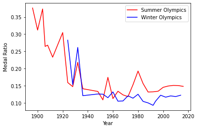

```python
plt.plot(summer_medals.Year, summer_medals_ratio.medal_ratio, color = "red", label = "Summer Olympics")
plt.plot(winter_medals.Year, winter_medals_ratio.medal_ratio, color = "blue", label = "Winter Olympics")
plt.xlabel("Year")
plt.ylabel("Medal Ratio")
plt.legend()
```

```
No handles with labels found to put in legend.
```

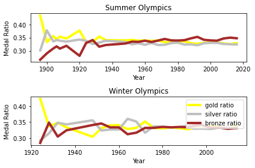

```python
fig, ax = plt.subplots(2)

ax[0].plot(summer_medals.Year, summer_medals_ratio.gold_ratio, marker='', color='yellow', linewidth=4, label = "gold ratio")
ax[0].plot(summer_medals.Year, summer_medals_ratio.silver_ratio, marker='', color='silver', linewidth=4, label = "silver ratio")
ax[0].plot(summer_medals.Year, summer_medals_ratio.bronze_ratio, marker='', color='brown', linewidth=4, label = "bronze ratio")
plt.legend(loc=1)
ax[0].set_xlabel("Year")
ax[0].set_ylabel("Medal Ratio")
ax[0].set_title("Summer Olympics")

ax[1].plot(winter_medals.Year, winter_medals_ratio.gold_ratio, marker='', color='yellow', linewidth=4, label = "gold ratio")
ax[1].plot(winter_medals.Year, winter_medals_ratio.silver_ratio, marker='', color='silver', linewidth=4, label = "silver ratio")
ax[1].plot(winter_medals.Year, winter_medals_ratio.bronze_ratio, marker='', color='brown', linewidth=4, label = "bronze ratio")
ax[1].legend(loc=1)
ax[1].set_xlabel("Year")
ax[1].set_ylabel("Medal Ratio")
ax[1].set_title("Winter Olympics")

plt.tight_layout()
```

Both medal ratio and relative percentages of gold, silver and bronze medals have stabilised, which may be due to establishing norms within the 2 competitions.

# Submit 2-3 key points you may have discovered about the data, e.g. new relationships? Aha's! Did you come up with additional ideas for other things to review?

1. Age gap between male and female athletes during the Winter is much smaller compared to Summer
2. Percentage of participants who won medals and ratio of medals have stabilised
3. Differences between number of participants and type of sport for the two events - required to be analysed separately

# Did you prove or disprove any of your initial hypotheses? If so, which one and what do you plan to do next?

My first hypothesis is the male:female ratio has decreased over time.

```python
gender_ratio_summer = sqldf.run('''SELECT
                        Year,
                        CAST(SUM(CASE WHEN Sex = "M" THEN 1 ELSE 0 END) AS float) / CAST(SUM(CASE WHEN Sex = "F" THEN 1 ELSE 0 END) AS float)
                          AS Ratio
                     FROM summer_events
                     GROUP BY Year
                    ''')

gender_ratio_winter = sqldf.run('''SELECT
                        Year,
                        CAST(SUM(CASE WHEN Sex = "M" THEN 1 ELSE 0 END) AS float) / CAST(SUM(CASE WHEN Sex = "F" THEN 1 ELSE 0 END) AS float)
                          AS Ratio
                     FROM winter_events
                     GROUP BY Year
                    ''')
```

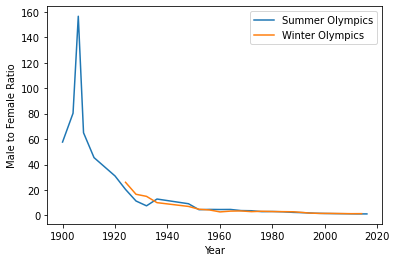

```python
plt.plot(gender_ratio_summer.Year, gender_ratio_summer.Ratio,label="Summer Olympics")
plt.plot(gender_ratio_winter.Year, gender_ratio_winter.Ratio,label="Winter Olympics")
plt.xlabel("Year")
plt.ylabel("Male to Female Ratio")
plt.legend()
```

Assumption is correct - Male:Female ratio has decreased over time.

# What additional questions are you seeking to answer?

1. Whether my next two hypothesis are correct (tested using A/B testing)
2. What other factors related to each athlete are affecting their performances for each event?